# Constructing and Analyzing DAGs in dagitty and ggdag_demo

Laura Dee

2025-05-16

# Learning Objectives

- Understand what a DAG is and what it is useful for.
- Understand how to construct a DAG in R to represent a set of assumptions about causal relationships.
- Understand how to use a DAG to determine the consequences of including variables in a regression model.
- Understand how to use a DAG to select appropriate statistical analysis methods (with focus on regression models) for estimating causal relationships in non-randomized studies, including:
- how to identify variables that should be included in a regression model
- how to identify variables that should NOT be included in a regression model (colliders, bad controls)

For more recap and a live guide through ggdag and dagitty, I highly recommend this live demonstration and tutorial by Andrew Heiss [here](https://www.youtube.com/watch?v=uoAjyyToUTE)

# Using dagitty and ggdag in R

```r
## Load Packages
library(ggdag)
require(knitr)
library(dagitty)
require(tidyr)
require(ddplyr)
library(tidyverse)
```

# General syntax of the ggdag package:

- We created dagified objects with ggdag::dagify()
- We plotted our DAGs with ggdag::ggdag()
- We can also specify the coordinates of our nodes with a coordinate list
- We can use ggdag and dagitty packages can help us illustrate our paths and adjustment sets to fulfill the backdoor criterion

We will focus on two functions from the dagitty package: * dagitty::paths(): Returns a list with two components: paths, which gives the actual paths, and open, which shows whether each path is open (d-connected) or closed (d-separated). * dagitty::adjustmentSets(): Lists the sets of covariates that would allow for unbiased estimation of causal effects, assuming that the causal graph is correct.

# The Context: Let’s Start Simple

Let’s consider that we are investigating the effect of a species invasion on native biodiversity. We also know that land-use (nearby agricultural conversion) and nutrient additions (from fertilizer) help facilitate invasion, and nutrients can reduce native plant biodiversity ([Seabloom et al. 2021 *Ecology*](https://esajournals.onlinelibrary.wiley.com/doi/abs/10.1002/ecy.3218)). Climate also affects both native biodiversity and the invasive species’ abundances. We formalize this knowledge in the following DAG, after loading the packages we will use.

```
## Plot coordinates for graph not supplied! Generating coordinates, see ?coordinates for how to set your own.
```

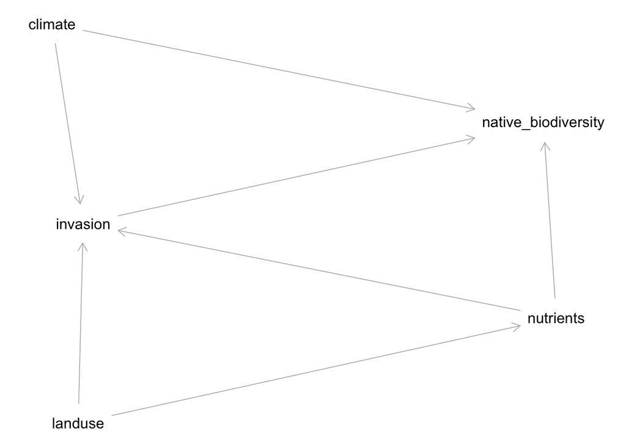

```r
## Specify the DAG
DAG_invasion_effects <- dagify(
  invasion ~ nutrients + climate + landuse,
  native_biodiversity ~ invasion + nutrients + climate,
  nutrients ~ landuse
)
plot(DAG_invasion_effects)
```

Next, we ned to identify which variable is the outcome of interest, and which is the treatment or exposure. Here are are considering the effect of invasion on native biodiversity. We can plot this nicely with ggdag. Here I set the seed when plotting because otherwise the DAG shows up in different orientations each time!

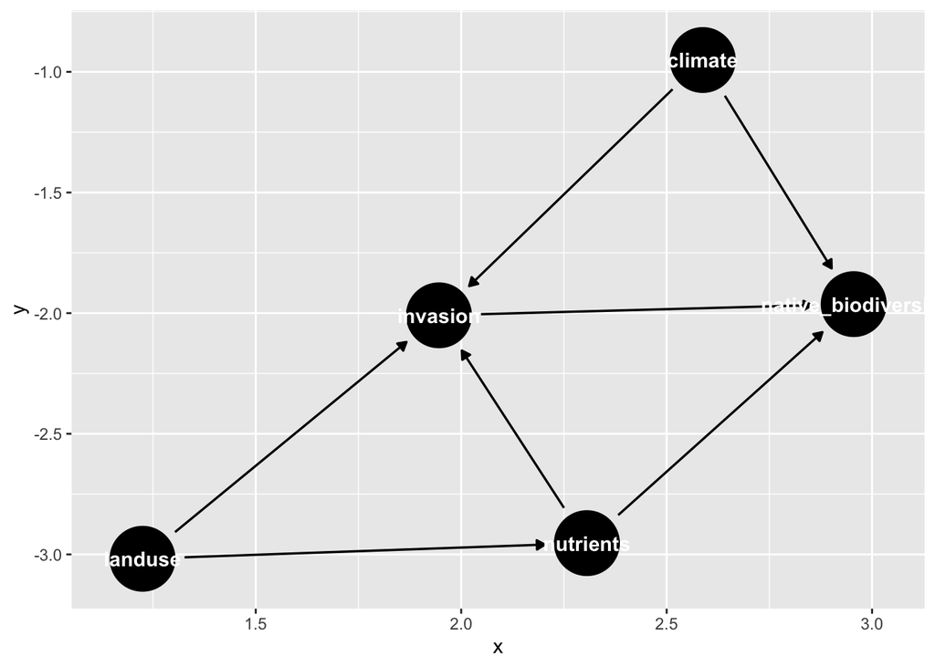

```r
DAG_invasion_effects <- dagify(
  invasion ~ nutrients + climate + landuse,
  native_biodiversity ~ invasion + nutrients + climate,
  nutrients ~ landuse ,
exposure = "invasion", #wont run if current biodiersity  also effects current exotic because then the graph is not acyclic
 outcome = "native_biodiversity",
labels = c(outcome = "Native Biodiversity",
           exposure = "Invasion"))

set.seed(124)
ggdag(DAG_invasion_effects,
       use_labels = "label")
```

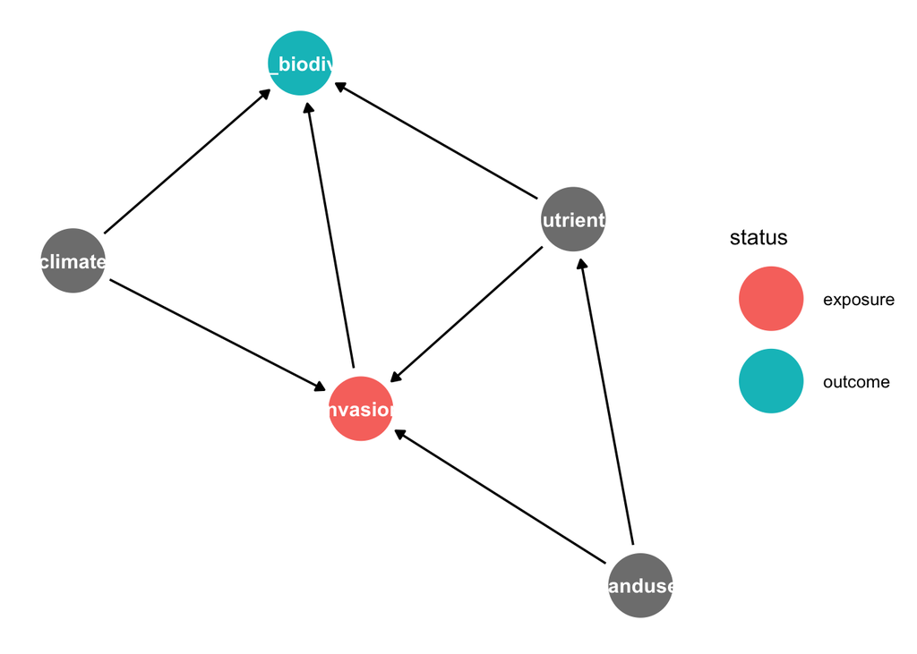

```r
ggdag_status(DAG_invasion_effects,
             use_labels = "label",
             text = TRUE,
             label_alpha = 0.5) + theme_dag()
```

To identify what must be controlled for, we can use adjustmentSets(). We can also have a summary of all possible paths in the DAG and identify which are open vs closed backdoors using paths().

This function takes a DAG, with a given “exposure” or “treatment variable” and an “outcome” and identifies open backdoors: confounding variables (common causes) that need to be controlled for.

```r
#identify the open paths that need to be adjusted for
paths(DAG_invasion_effects)
```

```
## $paths
## [1] "invasion -> native_biodiversity"
## [2] "invasion <- climate -> native_biodiversity"
## [3] "invasion <- landuse -> nutrients -> native_biodiversity"
## [4] "invasion <- nutrients -> native_biodiversity"
##
## $open
## [1] TRUE TRUE TRUE TRUE
```

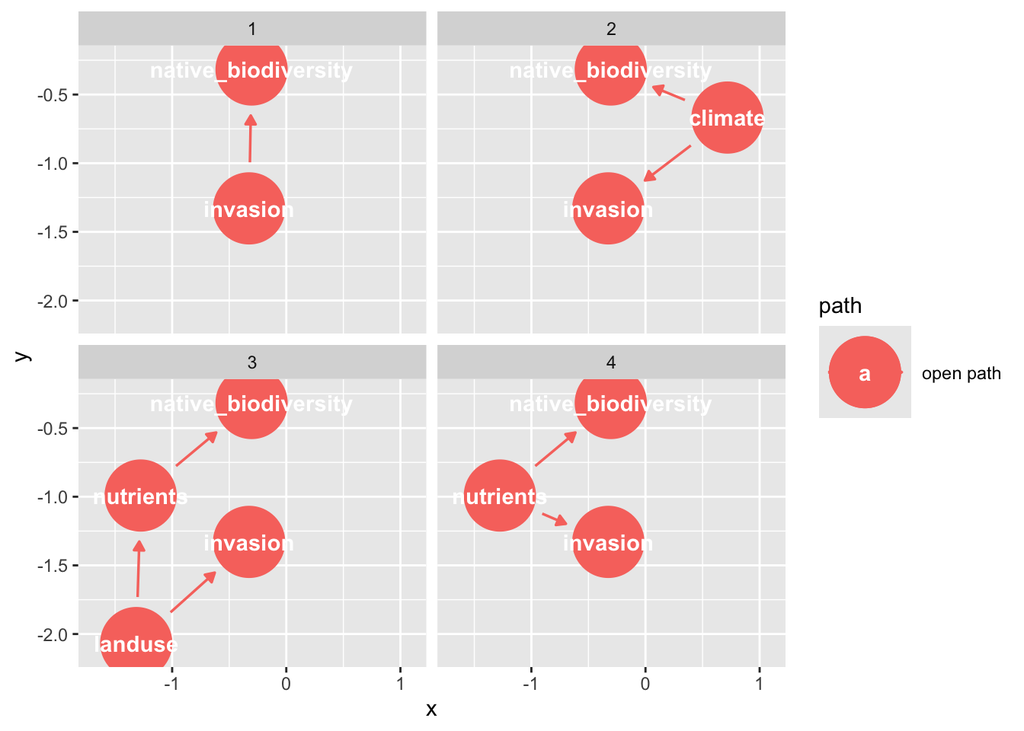

```r
#plot the open  paths
ggdag_paths(DAG_invasion_effects)
```

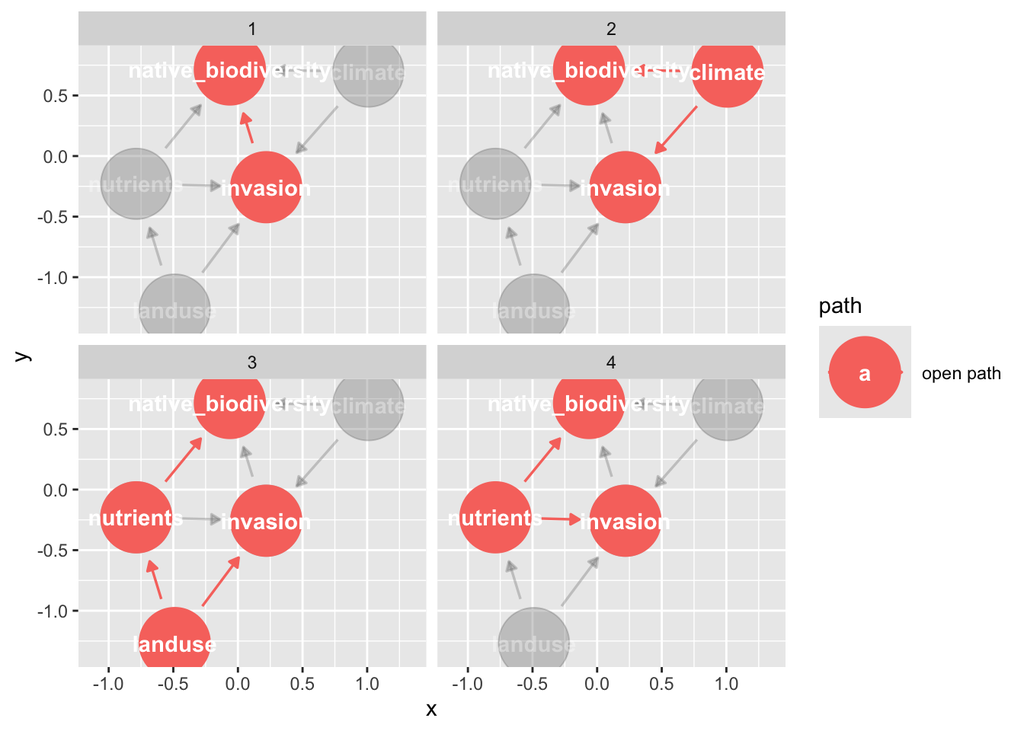

```r
ggdag_paths(DAG_invasion_effects, shadow = TRUE) #Also, do not forget to set the argument shadow = TRUE, so that the arrows from the adjusted nodes are included
```

We see under ’$paths' the paths we specified:$paths [1] “invasion -> native_biodiversity”  
[2] “invasion <- climate -> native_biodiversity”  
[3] “invasion <- landuse -> nutrients -> native_biodiversity” [4] “invasion <- nutrients -> native_biodiversity”

Then, ‘$open’ tells us whether each path is open. In this case, we see that all four paths are open. We want the first path - [1] “invasion -> native_biodiversity”- the causal path of interest to be open. But the other paths are confounding, so we would need to condition on nutrients, and climate to close these backdoor paths. We do not need to condition on landuse because nutrients is a descedent. We can see that here using the function ggdag_descendants()

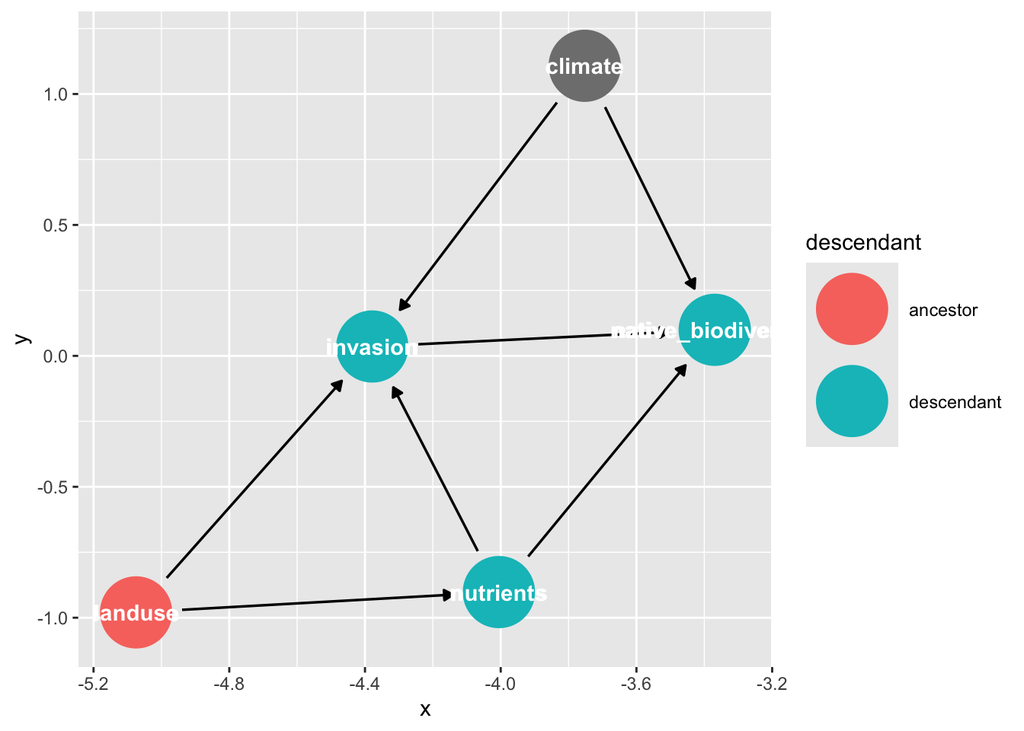

```r
#you can identify "descendant nodes"
ggdag_descendants(DAG_invasion_effects, "landuse")
```

```r
#identify the covariaters need to be adjusted for to meet the back-door criterion
adjustmentSets(DAG_invasion_effects)
```

```
## { climate, nutrients }
```

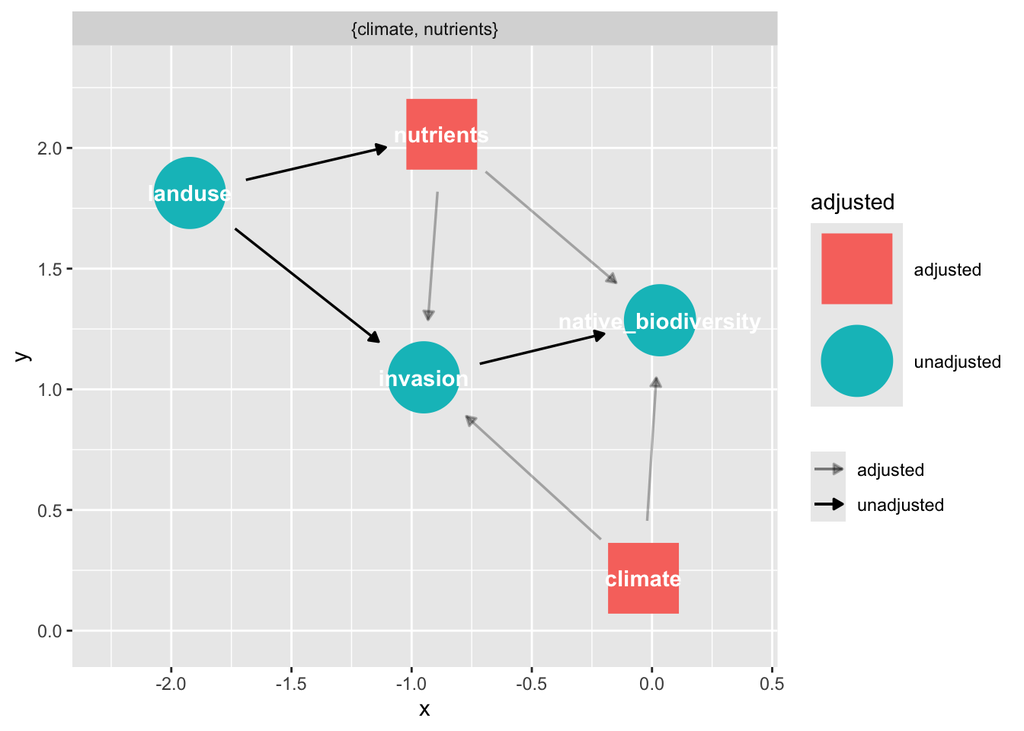

```r
# Finally, you can also visulaize the variables that need to be adjusted for (which is also told to you by the adjustmentSets() function
ggdag_adjustment_set(DAG_invasion_effects, shadow = TRUE)
```

```r
#Also, do not forget to set the argument shadow = TRUE, so that the arrows from the adjusted nodes are included.
```

We can also check to see which variables are conditionally independences in the DAG using impliedConditionalIndependencies().

```r
impliedConditionalIndependencies(DAG_invasion_effects)
```

```
## clmt _||_ lnds
## clmt _||_ ntrn
## lnds _||_ ntv_ | clmt, invs, ntrn
```

# A more complex case

I am currently working on a project led by Jane Catford with the Nutrient Network. We are analysing time-series data from 61 NutNet sites located in 14 countries and 6 continents. We will use species abundance and diversity trends over time (> or = 5 years) in control and nutrient-addition plots, and in sites that range in extent of human-driven environmental change.

One of the aims of this project is to test the following hypotheses: native species are competitively displaced by invading exotic species

The study design includes plots, within sites, with the treatment applied in treated plots (as opposed to control plots) for multiple years. Thus, we have subscripts for p for plot; s for site, and y for year.

| **Variable name** | **Description** |
| --- | --- |
| $\text{Native_psy}$ | Native plant species richness in the plot, site and year |
| $\text{Exotic_psy}$ | Exotic species abundance in the plot, site and year |
| $\text{Exotics_yr0}$ | Exotic species abundance in year 0 per plot (pre-treatment) |
| $\text{Native_yr0}$ | Native plant species richness in year 0 per plot |
| $\text{NPKTreatment}$ | Randomized experimental treatment: nutrient addition |
| $\text{Ndep_sy}$ | Nitrogen deposition for a site and year |
| $\text{Climate_sy}$ | Climate conditions for a site and year |
| $\text{SoilFert_yr0}$ | Soil feritility for each plot in the pre-treatment year |
| $\text{livestock_sy}$ | livestock grazing by site and year |
| $\text{Dist_to_Road_s}$ | Distance to road for each site |
| $\text{Oldfield_past_s }$ |  |
| $\text{pastlivestock_yr0}$ | Past grazing for each site (pre-treatment) |

A Note: The challenge is DAGs need to be *Acyclic* - so no feedbacks! However, we also hypothesize that native species richness can reduce invasion probabiliy and success by occupying a greater amount of niche space.